# Analysis of simulated data documentation

Steve and Jonathan

2019-10-02

# 1 Data

The data is simulated as per the writeup [here](https://cygubicko.github.io/wash/simulations_writeup.html), except that $\beta_k$, $k = 1,2,3$ are fixed.

- Jointly simulated $\epsilon_{ik}$ with $\mu_k = \mathbf{0}$ and covariance $\mathbf{\Sigma}$
- It has 3000 households per year repeatedly collected for 30 years.

| hhid | years | wealthindex | y1 | y2 | y3 | y1bin | y2bin | y3bin |
| --- | --- | --- | --- | --- | --- | --- | --- | --- |
| 173 | 2001 | 1.01 | 0.941 | 0.581 | 0.493 | 1 | 0 | 0 |
| 173 | 2002 | -0.76 | 0.14 | -0.511 | -0.311 | 1 | 0 | 1 |
| 173 | 2003 | 0.075 | -0.795 | 0.126 | -0.294 | 1 | 0 | 1 |
| 173 | 2004 | -0.402 | -0.346 | -0.411 | -0.904 | 1 | 0 | 0 |
| 173 | 2005 | -2.427 | -1.052 | -2.141 | -1.903 | 1 | 0 | 0 |
| 173 | 2006 | -1.389 | 0.101 | -0.972 | -1.191 | 1 | 0 | 0 |
| 173 | 2007 | -0.086 | -0.273 | -0.319 | -0.599 | 0 | 0 | 1 |
| 173 | 2008 | 1.461 | -0.737 | 0.946 | -0.663 | 1 | 0 | 0 |
| 173 | 2009 | -1.84 | -0.69 | -1.404 | 0.214 | 1 | 1 | 0 |
| 173 | 2010 | -0.389 | 0.108 | -0.577 | -1.033 | 1 | 0 | 0 |

[output cut: 140 more lines]

# 2 Analysis

We use Bayesian multivariate generalized linear models with correlated group-specific terms via Stan to model the binary outcomes

- Random intercept model: Assume an intercept that is different for each year

In other words, the fitted model was specified as:

$$y_{ijk} = \beta0_{jk} + \beta1_kx_i + \epsilon_{ik}$$

```
    model <- stan_mvmer(
        formula = list(
            y1bin ~ wealthindex + (1 | years) + (1 | hhid)
            , y2bin ~ wealthindex + (1 | years) + (1 | hhid)
            , y3bin ~ wealthindex + (1 | years) + (1 | hhid)
        )
        , data = sim_dflist[[1]]
        , family = list(binomial, binomial, binomial)
        , prior_intercept = normal(0, 1, autoscale = FALSE)
        , prior = normal(0, 1, autoscale = FALSE)
        , prior_aux = cauchy(0, 5, autoscale = FALSE)
        , prior_covariance = lkj(1, autoscale = FALSE)
        , ...
    )
```

## 2.1 Notes

Here we discuss some of the convergence statistics:

- **Rhat**: Also known as the potential scale reduction factor. `Rhat` compares the variation between the chains to the variation within the chains. It is approximately `1` if all the chains behave relatively the same and converge to the same region, i.e., the variance between chains will approximately equal the variance within the chains.
- **Effective Sample Size (n_eff)**: Chains exhibit some degree of autocorrelation due to non-independent MCMC draws. The lower the autocorrelation, the more the independent pieces of information we have about the posterior. The `n_eff` is the approximate number of independent draws having equal estimation accuracy as the sample of correlated draws. `n_eff` larger than `1000` is generally considered sufficient.
- **Monte Carlo Standard Error (MCSE)**: MCSE is calculated by dividing the posterior standard deviation by the square root of the ESS and it quantifies the amount of error introduced by the MCMC in approximating the posterior. A low MCSE, in comparison to the posterior standard deviation, will yield a desired higher number of `n_eff`, and vice versa.
- **Posterior Predicitive Check (PPC)**: Provides a way to assess whether the fitted model adequately fits the data. It involves using the fitted model to simulate the data and then comparing the simulated data to the observed data which an aim of replicating the key features of the observed data.
- **Posterior Intervals (PI)**: Also know as posterior uncertainity intervals or credible intervals provide a description of model parameters in probabilistic terms. Given the observed data, the priors and the model (data generating process), we can conclude that the probability that a parameter value is within some CI is some value.

# 3 Results

## 3.2 Fixed effects

Table below summarises the model output for the fixed effect parameters.

- The `n_eff` for some parameters (`y1|(intercep)` and `y2|(intercept)`) are much lower than the posterior samples. This could be as a result of correlated samples.
- However, `Rhat < 1.1` (though not a guanrantee for convergence but generally recommended) for all the fixed parameters

|  | mean | mcse | sd | 2.5% | 25% | 50% | 75% | 97.5% | n_eff | Rhat |
| --- | --- | --- | --- | --- | --- | --- | --- | --- | --- | --- |
| y1\|(Intercept) | 0.3038 | 0.0035 | 0.1013 | 0.1068 | 0.2379 | 0.3039 | 0.3694 | 0.5033 | 856 | 1.004 |
| y1\|wealthindex | 0.3993 | 0 | 0.0075 | 0.3847 | 0.3942 | 0.3993 | 0.4044 | 0.4142 | 25664 | 0.9999 |
| y2\|(Intercept) | 0.2972 | 0.0015 | 0.0603 | 0.1771 | 0.2576 | 0.2979 | 0.3369 | 0.4156 | 1672 | 1.0013 |
| y2\|wealthindex | 0.8112 | 0 | 0.0083 | 0.7948 | 0.8056 | 0.8112 | 0.8169 | 0.8275 | 28918 | 0.9998 |
| y3\|(Intercept) | 0.3784 | 0.0032 | 0.1342 | 0.1113 | 0.2899 | 0.3787 | 0.4675 | 0.6418 | 1793 | 1.0009 |
| y3\|wealthindex | 0.4989 | 0 | 0.0079 | 0.4834 | 0.4936 | 0.499 | 0.5042 | 0.5145 | 26752 | 0.9998 |

## 3.3 Marginal Posterior Parameter Estimates Plots

Plots point estimates for each parameter along with credibility intervals. In this case we are plotting the $50\%$ uncertainty interval (thick horizontal lines) and the $90\%$ uncertainty interval (thin horizontal lines). In terms of interpretation, the $50\%$ uncertainty interval identifies where $50\%$ of the marginal distribution lies for each parameter.

### 3.3.1 Intercept and slope

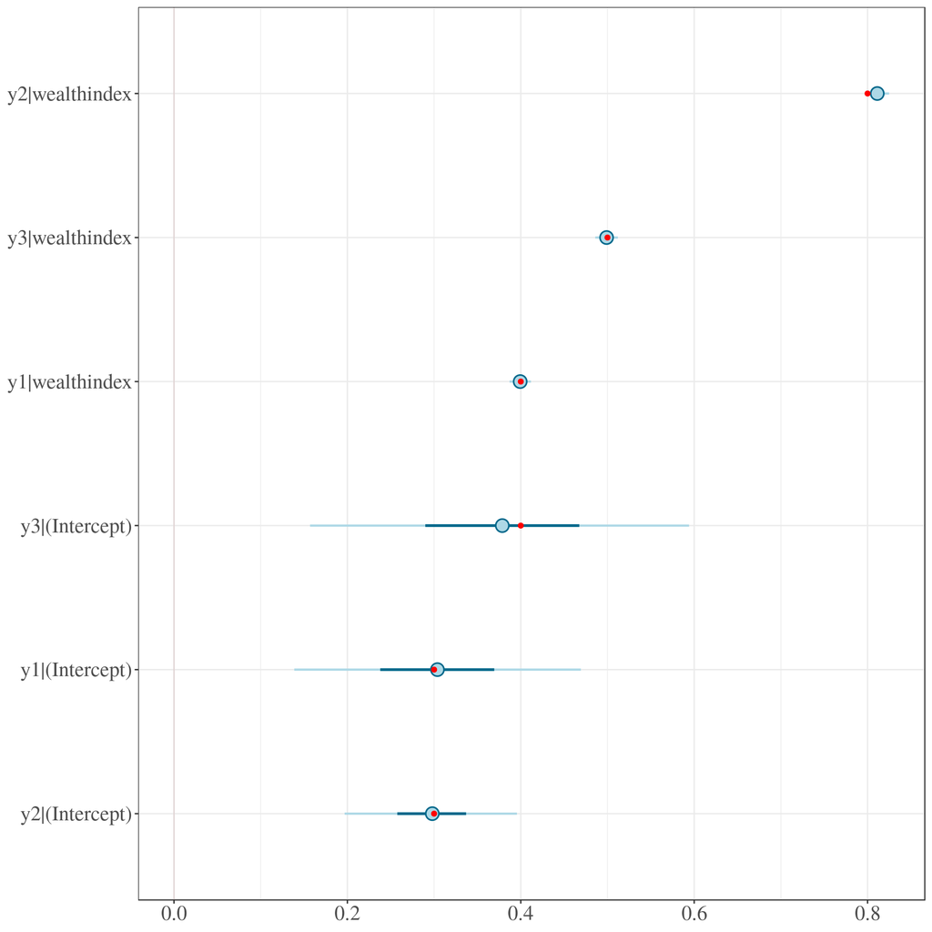

### 3.3.2 Year-specific estimates and variance

Here, we present estimates for the service 1 (`y1`) only. However, relatively similar trends are observed in the other remaining services.

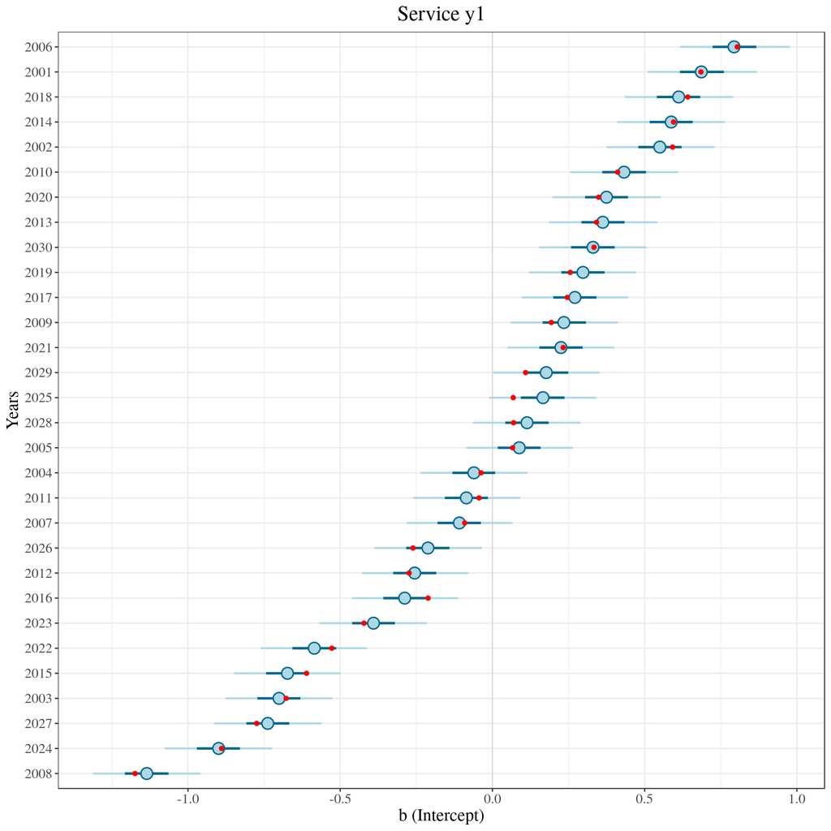

In general, our model is performing relatively well in estimating the `true` estimates of $\sigma^2$.

- For example: the year-specific intercepts, for `y1`, vary around the mean `y1|(Intercept)` estimate with a variance of `0.306` (95% `CI = [0.179, 0.525]`).

However, the CI estimates for some of variances are very wide:

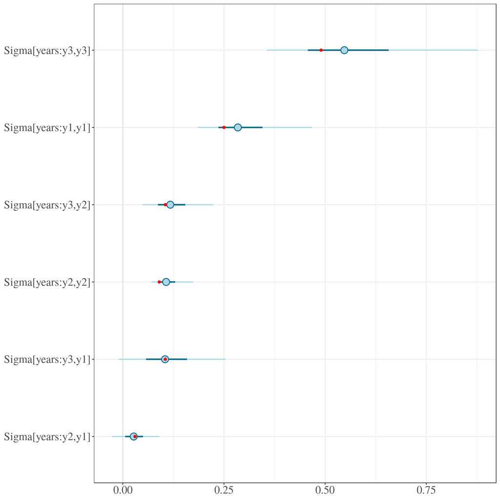

### 3.3.3 Household-specific estimates and variance

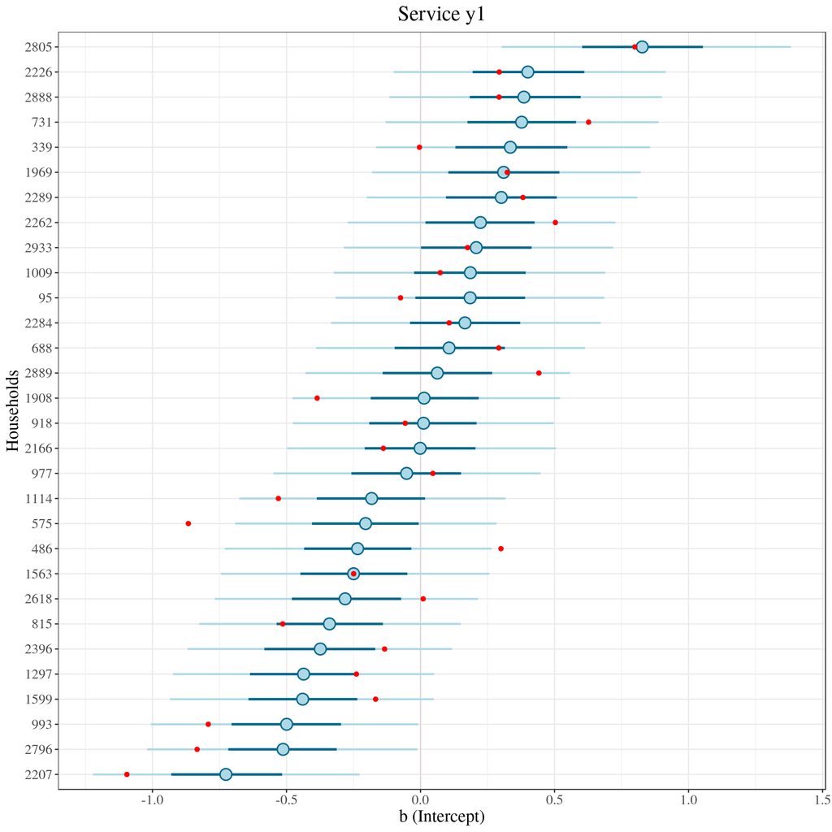

The estimates for household-specifiec variance for all the parameters are very close to the `true` values and have very narrow credible intervals.

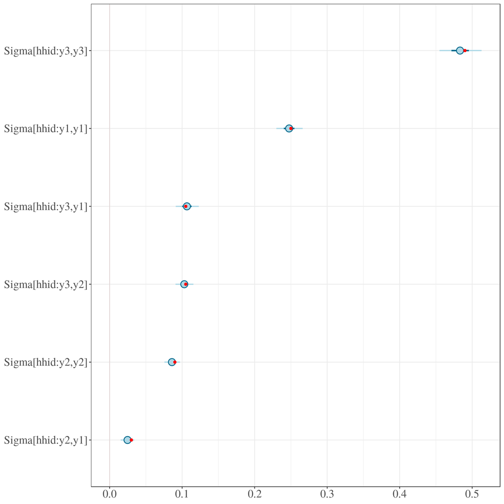

## 3.4 Correlation Estimates

The table summarises the model correlation estimates.

- The household level correlation estimates are very close to the respective `true` parameter values
- Though not as close as household level correlation estimates, year level estimates are also good

| term | group | true_value | estimate | diff |
| --- | --- | --- | --- | --- |
| cor_y1.y2.hhid | hhid | 0.2 | 0.16896701234908 | 0.03 |
| cor_y1.y3.hhid | hhid | 0.3 | 0.308389554230486 | 0.01 |
| cor_y2.y3.hhid | hhid | 0.5 | 0.504962498613137 | 0 |
| cor_y1.y2.years | years | 0.2 | 0.156188959543626 | 0.04 |
| cor_y1.y3.years | years | 0.3 | 0.269123442805321 | 0.03 |
| cor_y2.y3.years | years | 0.5 | 0.489418893829994 | 0.01 |